# BCB420: Assignment 1- Data Selection & Processing

Areej Negm

```r
# Packages required
if (! requireNamespace("BiocManager", quietly = TRUE)) {
  install.packages("BiocManager")
}
if (! requireNamespace("Biobase", quietly = TRUE)) {
  BiocManager::install("Biobase")
}
if (! requireNamespace("edgeR", quietly = TRUE)) {
  BiocManager::install("edgeR")
}
if (!requireNamespace("biomaRt", quietly = TRUE)) {
   BiocManager::install("biomaRt")
}
if (! requireNamespace("GEOquery", quietly = TRUE)) {
  BiocManager::install("GEOquery")
}
```

```
## Setting options('download.file.method.GEOquery'='auto')
```

```
## Setting options('GEOquery.inmemory.gpl'=FALSE)
```

```r
if (!requireNamespace("GEOmetadb", quietly = TRUE)){
  BiocManager::install("GEOmetadb")
}

library(BiocManager)
library(Biobase)
library(edgeR)
library(biomaRt)
library(GEOquery)
library(GEOmetadb)
```

# Selecting an Expression Dataset

The expression data set I chose is GSE157852 Human Pluripotent Stem Cell-Derived Neural Cells and Brain Organoids Reveal SARS-CoV-2 Neurotropism Predominates in Choroid Plexus Epithelium

# Overview of Data

First, I need to download my chosen dataset

```r
gse <- getGEO("GSE157852",GSEMatrix=FALSE)
```

[output not shown]

[output not shown]

[output not shown]

[output not shown]

[output not shown]

[output not shown]

[output not shown]

[output not shown]

[output not shown]

[output not shown]

[output not shown]

[output not shown]

[output not shown]

[output not shown]

[output not shown]

```r
if (! exists("GSE157852")) {
gse <- getGEO("GSE157852", GSEMatrix = FALSE)
}
```

[output not shown]

[output not shown]

[output not shown]

[output not shown]

[output not shown]

[output not shown]

[output not shown]

[output not shown]

[output not shown]

[output not shown]

[output not shown]

[output not shown]

[output not shown]

[output not shown]

GEO description of dataset

```r
gpl <- names(GPLList(gse))[1]
gpl_info <- Meta(getGEO(gpl))
```

```
## File stored at:
```

```
## /var/folders/mq/kpnp139s4lz4hx67xrhn_7zr0000gn/T//RtmpgNnwpL/GPL21697.soft
```

```r
gpl_info$title
```

```
## [1] "NextSeq 550 (Homo sapiens)"
```

```r
gpl_info$submission_date
```

```
## [1] "Apr 05 2016"
```

```r
gpl_info$last_update_date
```

```
## [1] "Dec 05 2018"
```

```r
gpl_info$organism
```

```
## [1] "Homo sapiens"
```

```r
length(gpl_info$series_id)
```

```
## [1] 291
```

```r
length(gpl_info$sample_id)
```

```
## [1] 9128
```

# Downloading Dataset

```r
sfiles = getGEOSuppFiles('GSE157852')
fnames = rownames(sfiles)
countsdata = read.delim(fnames[1],header = TRUE,check.names = FALSE)
```

# Cleaning & Filtering Dataset

How many expressions do we have measurements for?

```r
countsdata <- read.table("GSE157852/GSE157852_CPO_RawCounts.txt", header=TRUE)
dim(countsdata)
```

```
## [1] 29755     9
```

```
[1] 29755     9
```

There is 29755 genes in this dataset. However there is only one column, this is because they have not separated the samples into individual columns. I used read.table() function and set header to TRUE to get all 9 samples.

```r
#renaming Columns to corresponding samples, as well as labeling genes column

countsdata <- cbind(rownames(countsdata), countsdata)
rownames(countsdata) <- NULL
colnames(countsdata) <- c( "Genes", "CPO_Mock_72hpi_S1", "CPO_Mock_72hpi_S2", "CPO_Mock_72hpi_S3", "CPO_SARS-CoV-2_24hpi_S4", "CPO_SARS-CoV-2_24hpi_S5", "CPO_SARS-CoV-2_24hpi_S6", "CPO_SARS-CoV-2_72hpi_S7", "CPO_SARS-CoV-2_72hpi_S8", "CPO_SARS-CoV-2_72hpi_S9")
```

**Filter weakly expressed genes from my dataset** The paper indicates that n = 3 biological replicates.

```r
#Translate reads into counts per million using edgeR package
cpms = edgeR::cpm(countsdata[,2:9])
rownames(cpms) <- countsdata[ ,1]
# keep counts greater than 1cpm, n = 3 biological replicates
keeps = rowSums(cpms >1) >= 3
filtered_countsdata = countsdata[keeps, ]
dim(filtered_countsdata)
```

```
## [1] 12849    10
```

[1] 12849 10

16906 counts were removed.

**Check for Duplicates**

```r
filtered_countsGenes <- data.frame(table(filtered_countsdata$Genes))
colnames(filtered_countsGenes) <- c("Genes", "Frequency")

sum(filtered_countsGenes$Frequency > 1)
```

```
## [1] 0
```

[1] 0 No duplicates found

# Visulization

**Density Plot**

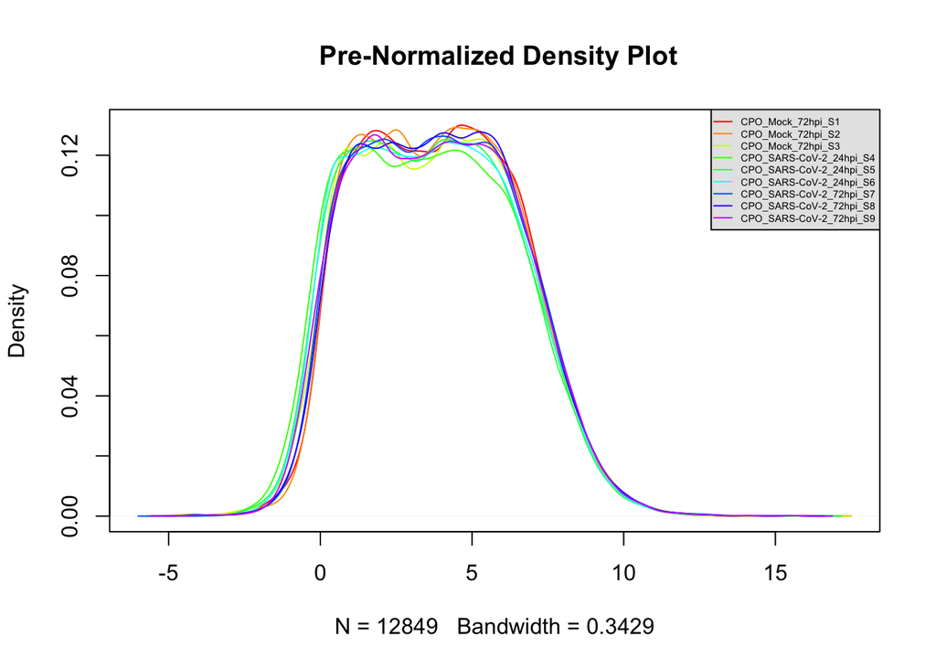

```r
countsDensity <- apply(log2(edgeR::cpm(filtered_countsdata[ ,2:10])), 2, density)
#
xlim <- 0; ylim <- 0
for (i in 1:length(countsDensity)) {
 xlim <- range(c(xlim, countsDensity[[i]]$x));
 ylim <- range(c(ylim, countsDensity[[i]]$y))
}

# C
density_cols <- rainbow(length(filtered_countsdata))
ltys <- rep(1, length(countsDensity))

plot(countsDensity[[1]], xlim=xlim, ylim=ylim, type="n",
     main=" Pre-Normalized Density Plot")
for (i in 1:length(countsDensity)){
  lines(countsDensity[[i]], col=density_cols[i], lty=ltys[i])
}
# legend
legend("topright", colnames(filtered_countsdata)[2:10], col=density_cols, lty=ltys, cex=0.45,
border ="blue", text.col = "black", merge = TRUE, bg = "gray90")
```

**Original Boxplot without Normalization**

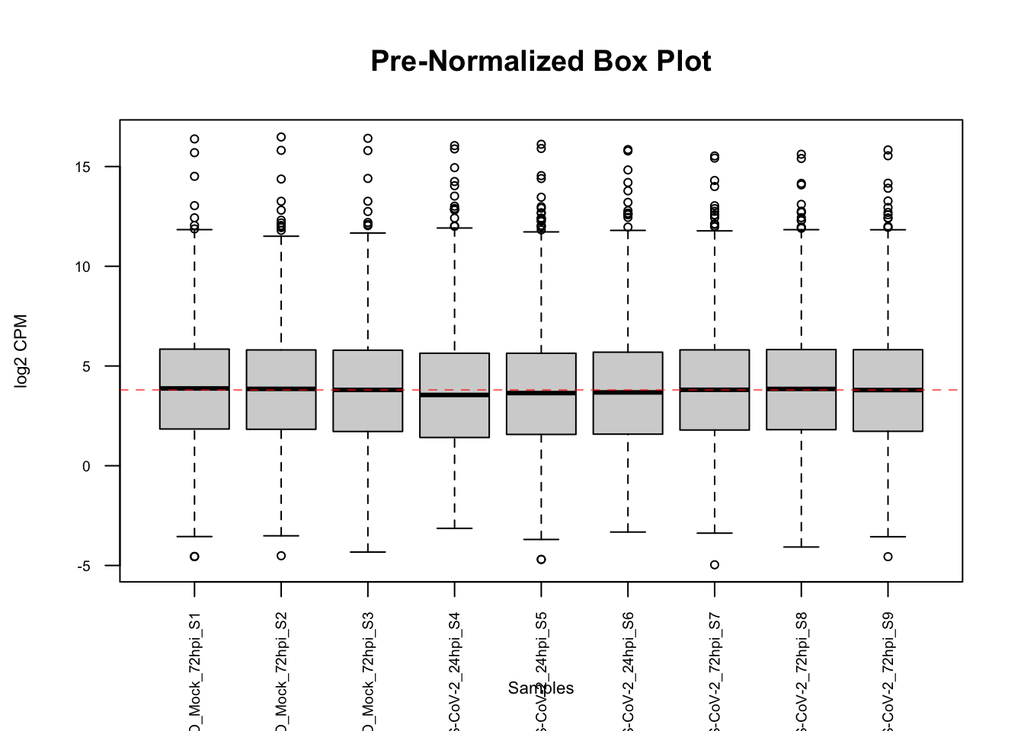

```r
preNormalbox <- log2(cpm(filtered_countsdata[ ,2:10]))

boxplot(preNormalbox, outline=TRUE, xlab = "Samples", ylab = "log2 CPM",
las = 2, cex = 0.7, cex.lab = 0.7,
cex.axis = 0.6, main = "Pre-Normalized Box Plot")
abline(h = median(apply(preNormalbox, 2, median)), col = "red", lwd = 0.6, lty = "dashed")
```

# Apply Normalization

The paper indicates that raw counts were already normalized in order to make the data comparable. Raw sequencing data from Choroid plexus organoids (CPOs), human choroid plexus tissue and SARS-COV-2 were first TPM normalized (transcripts per million) to obtain TPM values for each transcripts. TPM expression values were then log10(TPM + 1) transformed for plotting individual expression values.

```r
## first define samples and categorize them in their designated reatment
samples <- data.frame(lapply(colnames(filtered_countsdata)[2:10],
FUN=function(x){unlist(strsplit(x, split = "_", 3))[c(1,2,3)]}))
colnames(samples) <- colnames(filtered_countsdata)[2:10]
rownames(samples) <- c("Tissue","Sample Type", "Condition") #assign the 3 groups
samples <- data.frame(t(samples))
```

The method I will use is edgeR’s trimmed mean of M values (TMM) normalization method. Because this dataset has already been TPM normalized in order to compare gene count comparisons between samples, TMM normalization is the ideal candidate because it is robust and accounts for library size as well as large differences in Deferentially expressed genes.

```r
filtered_dataMatrix<- as.matrix(filtered_countsdata[ ,2:10])
rownames(filtered_dataMatrix) <- filtered_countsdata$Gene
d = DGEList(counts=filtered_dataMatrix,  group=samples$Condition)
d = calcNormFactors(d)
normalized_counts <- cpm(d)
```

**Normalized Density Plot**

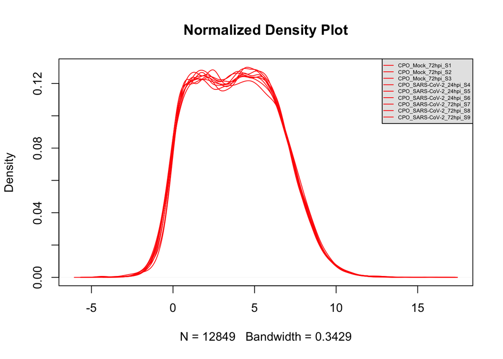

```r
normalDensity <- apply(log2(normalized_counts), 2, density)
xlim <- 0; ylim <- 0
for (i in 1:length(normalDensity)) {
 xlim <- range(c(xlim, normalDensity[[i]]$x));
 ylim <- range(c(ylim, normalDensity[[i]]$y))
}

cols <- rainbow(length(normalized_counts))
ltys <- rep(1, length(normalDensity))

plot(normalDensity[[1]], xlim=xlim, ylim=ylim, type="n",
     main="Normalized Density Plot")
for (i in 1:length(normalDensity)){
  lines(normalDensity[[i]], col=cols[i], lty=ltys[i])
}
# legend
legend("topright", colnames(normalized_counts), col=cols, lty=ltys, cex=0.45,
border ="blue", text.col = "black", merge = TRUE, bg = "gray90")
```

There isnt much of a difference between the pre-normalized plot and the normalized plot. I also dont know why its red.

**Normalized Box Plot**

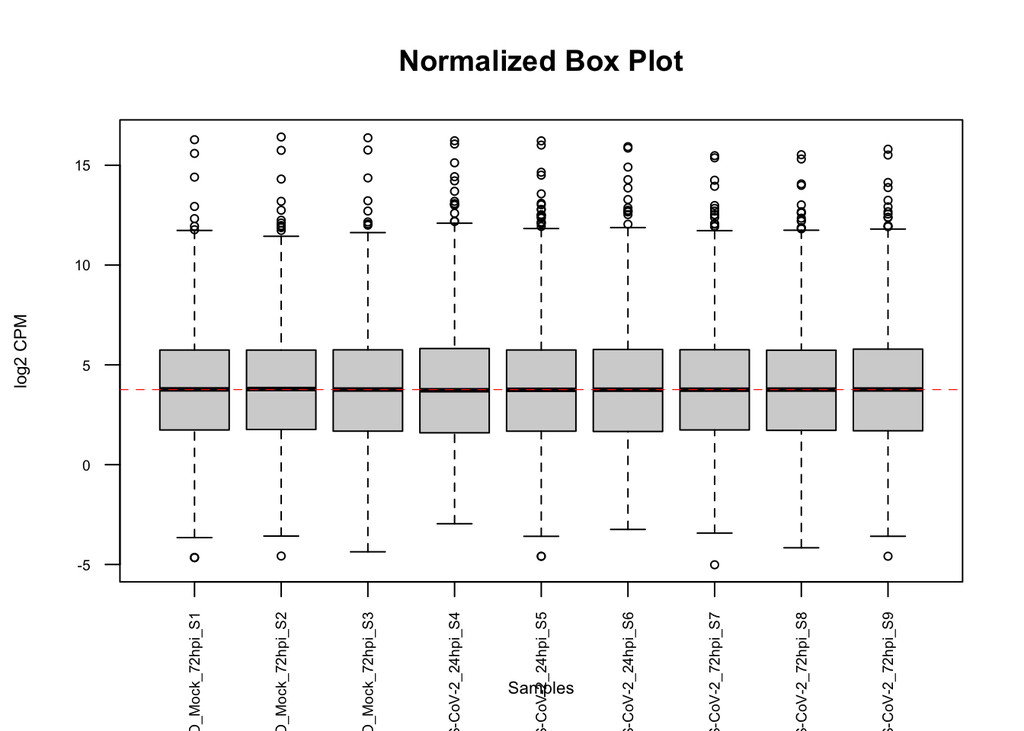

```r
Normalbox <- log2(normalized_counts)

boxplot(Normalbox, outline=TRUE, xlab = "Samples", ylab = "log2 CPM",
las = 2, cex = 0.7, cex.lab = 0.7,
cex.axis = 0.6, main = "Normalized Box Plot")
abline(h = median(apply(Normalbox, 2, median)), col = "red", lwd = 0.6, lty = "dashed")
```

Hasnt changed much. **MSD Plot**

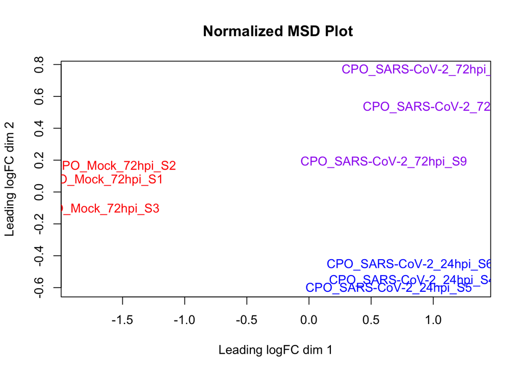

```r
edgeR::plotMDS.DGEList(d, labels=colnames(normalized_counts),
               col=c(rep("red",3),rep("blue",3),rep("purple",3)),
               main=" Normalized MSD Plot")
```

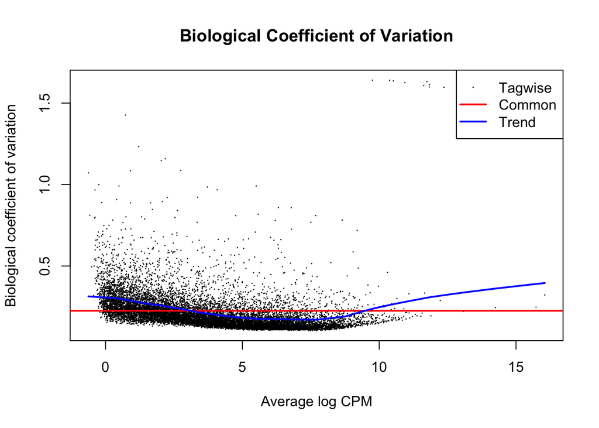

```r
modelDesign <- model.matrix(~samples$Condition)
d_value <- edgeR::estimateDisp(d, modelDesign)
edgeR::plotBCV(d_value ,col.tagwise = "black",col.common = "red")
title("Biological Coefficient of Variation")
```

This plot represents the mean-varian relationship. The common dispersion line at approx. 0.2 is considered reasonable and could therefore favorably influence our DE gene detection. [3]